# 10 Web map layers

Packages steps 03/04/07's already-cited outputs into small, web-friendly files for docs/. No claims are tagged to this step directly (per steps/10's own Evidence section) -- which underlying claims back each layer is documented in those steps; this notebook only simplifies, reprojects, and exports. City-of-Revelstoke-sourced geometry never appears in any output here (checked explicitly below): only ParcelMap BC and NRCan HRDEM are used for anything published to docs/.

```python
processed_dir = "data/processed"
raw_dir = "data/raw"
docs_data_dir = "docs/data"
project_crs = "EPSG:26911"
web_crs = "EPSG:4326"

# Geometry simplification tolerance (judgment call): applied in the
# project CRS (metres) before reprojecting to EPSG:4326 for the web, so
# the tolerance means the same real-world distance for every layer.
simplify_tolerance_m = 5

max_file_size_mb = 25

# Elevation-band raster is coarsened before vectorizing (native 1 m HRDEM
# pixels would make an enormous polygon count for a web layer); factor
# is in pixels per side, e.g. 10 means one output pixel per 10x10 block.
elevation_band_coarsen_factor = 10

# Hillshade PNG: HRDEM's native 1 m resolution is far more than a web
# image needs; every Nth pixel is kept in each dimension.
hillshade_downsample_factor = 8
```

## AOI layer

Step 03's AOI polygon (C063), simplified in the project CRS then reprojected to EPSG:4326 for the web.

```python
import os

import geopandas as gpd

os.makedirs(docs_data_dir, exist_ok=True)

aoi = gpd.read_file(f"{processed_dir}/03_aoi.gpkg")
# Explicit allowlist (not just the Checks cell's blocklist below) -- defense in depth in case
# 03_aoi.gpkg ever gains a column the blocklist didn't anticipate.
aoi_simplified = aoi[["osm_way_id", "name", "geometry"]].copy()
aoi_simplified["geometry"] = aoi_simplified.geometry.simplify(simplify_tolerance_m)
aoi_web = aoi_simplified.to_crs(web_crs)
aoi_path = f"{docs_data_dir}/10_aoi.geojson"
aoi_web.to_file(aoi_path, driver="GeoJSON")
print(f"{aoi_path}: {os.path.getsize(aoi_path)} bytes")
aoi_web.total_bounds
```

```
docs/data/10_aoi.geojson: 2576 bytes
```

```
array([-118.1659459,   50.9481612, -118.0891038,   50.9894892])
```

## Lifts layer

OSM lift geometry (already EPSG:4326, no reprojection needed) from S050's saved Overpass result, joined to step 03's lift crosswalk (data/processed/03_lift_crosswalk.csv) for DEM-derived vertical rise and the proposed master-plan map_ref.

```python
import json

import pandas as pd
from shapely.geometry import LineString, shape

with open(f"{raw_dir}/S050_overpass_lifts_pistes.json", encoding="utf-8") as f:
    overpass = json.load(f)

lift_crosswalk = pd.read_csv(f"{processed_dir}/03_lift_crosswalk.csv")
crosswalk_by_id = lift_crosswalk.set_index("osm_id")

lift_rows = []
for el in overpass["elements"]:
    if el.get("type") != "way" or "aerialway" not in el.get("tags", {}):
        continue
    if el["id"] not in crosswalk_by_id.index:
        continue
    coords = [(pt["lon"], pt["lat"]) for pt in el["geometry"]]
    row = crosswalk_by_id.loc[el["id"]]
    lift_rows.append({
        "osm_id": el["id"], "name": el["tags"].get("name"),
        "aerialway_type": row["aerialway_type"], "proposed_map_ref": row["proposed_map_ref"],
        "dem_vert_rise_m": row["dem_vert_rise_m"], "vert_rise_delta_m": row["vert_rise_delta_m"],
        "geometry": LineString(coords),
    })
lifts = gpd.GeoDataFrame(lift_rows, crs=web_crs)
print(f"{len(lifts)} lifts (of {len(lift_crosswalk)} in the crosswalk)")

lifts_projected = lifts.to_crs(project_crs)
lifts_projected["geometry"] = lifts_projected.geometry.simplify(simplify_tolerance_m)
lifts_web = lifts_projected.to_crs(web_crs)
lifts_path = f"{docs_data_dir}/10_lifts.geojson"
lifts_web.to_file(lifts_path, driver="GeoJSON")
print(f"{lifts_path}: {os.path.getsize(lifts_path)} bytes")
```

```
7 lifts (of 7 in the crosswalk)
docs/data/10_lifts.geojson: 2362 bytes
```

## Runs layer

Step 03 already computed per-run difficulty and DEM slope stats (data/processed/03_runs.gpkg); this just simplifies and reprojects.

```python
runs = gpd.read_file(f"{processed_dir}/03_runs.gpkg")
# Explicit allowlist, same reasoning as the AOI layer above.
runs_keep_cols = ["osm_id", "name", "osm_difficulty", "length_m", "vert_drop_m",
                   "mean_slope_deg", "max_slope_deg", "geometry"]
runs_simplified = runs[runs_keep_cols].copy()
runs_simplified["geometry"] = runs_simplified.geometry.simplify(simplify_tolerance_m)
runs_web = runs_simplified.to_crs(web_crs)
runs_path = f"{docs_data_dir}/10_runs.geojson"
runs_web.to_file(runs_path, driver="GeoJSON")
print(f"{runs_path}: {os.path.getsize(runs_path)} bytes, {len(runs_web)} runs")
```

```
docs/data/10_runs.geojson: 79877 bytes, 116 runs
```

## Elevation bands layer: rebuild the band raster

Step 04 only wrote a vertical-extent-by-band table (data/processed/04_elevation_bands.csv: bottom_m/top_m per band, no area or geometry column), not polygons, so the band raster is rebuilt here from the same DEM clip and the same band edges, then vectorized below. Coarsened first (elevation_band_coarsen_factor) since native 1 m pixels would produce an unusably large polygon count for a simplified web layer.

```python
import sys

import numpy as np

sys.path.insert(0, "src")
from resort.dem import clip_dem

bands = pd.read_csv(f"{processed_dir}/04_elevation_bands.csv")
band_edges = bands["bottom_m"].tolist() + [bands["top_m"].iloc[-1]]
band_labels = bands["band"].tolist()

dem = clip_dem(tuple(aoi.total_bounds), project_crs, buffer_m=0)
dem_coarse = dem.coarsen(
    x=elevation_band_coarsen_factor, y=elevation_band_coarsen_factor, boundary="trim"
).mean()
elev_arr = dem_coarse.values[0]
# recalc=True is required: xarray's coarsen().mean() is CRS-unaware and never updates
# the cached GeoTransform on the array's spatial_ref coordinate, so the default
# .rio.transform() silently hands back the PRE-coarsen (1 m) transform even though the
# array is now coarser -- caught by notebook-reviewer, verified directly against the DEM.
coarse_transform = dem_coarse.rio.transform(recalc=True)
print(f"coarsened DEM shape: {elev_arr.shape} (from {dem.values[0].shape})")
```

```
coarsened DEM shape: (799, 829) (from (7994, 8296))
```

## Vectorize, dissolve, simplify, export

```python
from rasterio.features import shapes as rio_shapes

band_idx = np.digitize(elev_arr, band_edges) - 1
band_idx = np.clip(band_idx, 0, len(band_labels) - 1).astype("int32")
band_idx[np.isnan(elev_arr)] = -1

band_polygons = []
for geom, value in rio_shapes(band_idx, mask=(band_idx != -1), transform=coarse_transform):
    band_polygons.append({"band": band_labels[int(value)], "geometry": shape(geom)})

band_gdf = gpd.GeoDataFrame(band_polygons, crs=project_crs)
elevation_bands = band_gdf.dissolve(by="band", as_index=False)
# clip_dem's bounds are the AOI's rectangular bounding box, not its actual polygon shape, so
# without this the band polygons spill out well beyond the resort boundary into surrounding
# terrain -- clip to the real AOI polygon to match step 04's own area accounting.
aoi_union = aoi.geometry.union_all()
elevation_bands["geometry"] = elevation_bands.geometry.intersection(aoi_union)
elevation_bands = elevation_bands[~elevation_bands.geometry.is_empty]
elevation_bands["geometry"] = elevation_bands.geometry.simplify(simplify_tolerance_m)
elevation_bands_web = elevation_bands.to_crs(web_crs)
bands_path = f"{docs_data_dir}/10_elevation_bands.geojson"
elevation_bands_web.to_file(bands_path, driver="GeoJSON")
print(f"{bands_path}: {os.path.getsize(bands_path)} bytes, {len(elevation_bands_web)} band polygons")
```

```
docs/data/10_elevation_bands.geojson: 12620 bytes, 3 band polygons
```

## Funnel parcels layer

step 07 wrote per-parcel results only for the parcels that survived its full filter chain (data/processed/07_network_distances.csv -- the row count is printed by the code cell below, not stated here) -- not a stage-reached attribute for every candidate parcel, since that table was never exported. This layer therefore publishes only "passed the full funnel" parcels, not a richer pass/fail-per-stage breakdown; noted in steps/07's Open issues as a gap for a future revisit, not silently narrowed here.

Geometry is ParcelMap BC (S030/C065), not the City's own parcel fabric, per this step's own method and the licence rule.

```python
from resort.arcgis import fetch_parcelmap_bc

network_distances = pd.read_csv(f"{processed_dir}/07_network_distances.csv", dtype={"PID": str})
survivor_pids = set(network_distances["PID"].dropna())
print(f"{len(survivor_pids)} funnel-surviving parcels with a real PID "
      f"(of {len(network_distances)} rows -- some ParcelMap BC parcels have no PID)")

all_city_parcels = fetch_parcelmap_bc("MUNICIPALITY='Revelstoke, City of'", out_crs=project_crs)
funnel_parcels = all_city_parcels[all_city_parcels["PID"].isin(survivor_pids)].merge(
    network_distances, on="PID", how="left"
)
funnel_parcels["passed_full_funnel"] = True
print(f"matched {len(funnel_parcels)} of {len(survivor_pids)} survivor PIDs to live ParcelMap BC geometry")
```

```
183 funnel-surviving parcels with a real PID (of 190 rows -- some ParcelMap BC parcels have no PID)
```

```
matched 183 of 183 survivor PIDs to live ParcelMap BC geometry
```

## Simplify, reproject, export funnel parcels

```python
keep_cols = [
    "PID", "PARCEL_CLASS", "FEATURE_AREA_SQM", "passed_full_funnel",
    "network_dist_to_gondola_base_m", "network_dist_to_downtown_m", "geometry",
]
funnel_parcels_out = funnel_parcels[keep_cols].copy()
funnel_parcels_out["geometry"] = funnel_parcels_out.geometry.simplify(simplify_tolerance_m)
funnel_parcels_web = funnel_parcels_out.to_crs(web_crs)
funnel_path = f"{docs_data_dir}/10_funnel_parcels.geojson"
funnel_parcels_web.to_file(funnel_path, driver="GeoJSON")
print(f"{funnel_path}: {os.path.getsize(funnel_path)} bytes, {len(funnel_parcels_web)} parcels")
```

```
docs/data/10_funnel_parcels.geojson: 99080 bytes, 183 parcels
```

## Hillshade image

NRCan's HRDEM STAC item publishes a pre-rendered hillshade-dtm asset alongside the dtm asset itself; clipping that (a windowed read, same clip_dem helper, just a different URL) needs no new hillshade computation.

```python
HILLSHADE_URL = (
    "https://canelevation-dem.s3.ca-central-1.amazonaws.com/"
    "hrdem-mosaic-1m/2_4-mosaic-1m-dtm_hillshade.tif"
)
hillshade = clip_dem(tuple(aoi.total_bounds), project_crs, buffer_m=200, url=HILLSHADE_URL)
hillshade_arr = hillshade.values[0]
hillshade_small = hillshade_arr[::hillshade_downsample_factor, ::hillshade_downsample_factor]
print(f"hillshade array: {hillshade_arr.shape} -> downsampled to {hillshade_small.shape}")
```

```
hillshade array: (8506, 8809) -> downsampled to (1064, 1102)
```

## Write hillshade PNG

```python
import matplotlib.pyplot as plt

hillshade_path = f"{docs_data_dir}/10_hillshade.png"
plt.imsave(hillshade_path, np.nan_to_num(hillshade_small, nan=0), cmap="gray")
print(f"{hillshade_path}: {os.path.getsize(hillshade_path)} bytes")
```

```
docs/data/10_hillshade.png: 979494 bytes
```

## Map: all exported web layers together

A visual check that every layer lines up spatially before publishing, rendered over the clipped hillshade.

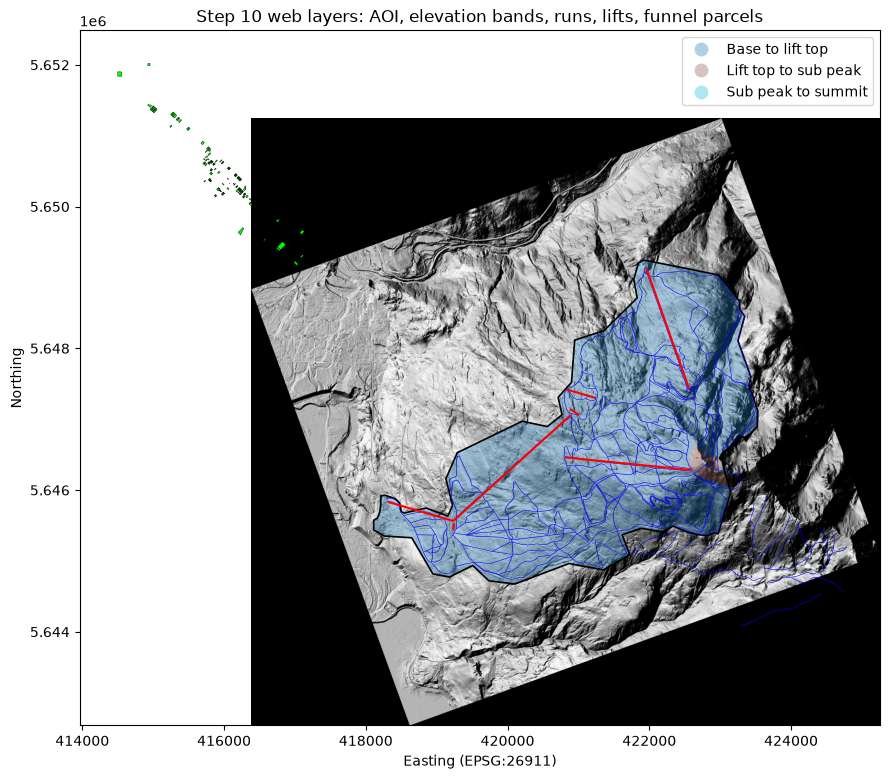

```python
fig, ax = plt.subplots(figsize=(9, 9))
extent = hillshade.rio.bounds()
ax.imshow(
    np.nan_to_num(hillshade_arr, nan=np.nanmin(hillshade_arr)), cmap="gray",
    extent=(extent[0], extent[2], extent[1], extent[3]), origin="upper",
)
aoi.boundary.plot(ax=ax, color="black", linewidth=1.2, label="AOI")
elevation_bands.plot(ax=ax, column="band", alpha=0.35, legend=True)
runs.plot(ax=ax, color="blue", linewidth=0.4)
lifts_projected.plot(ax=ax, color="red", linewidth=1.5)
funnel_parcels.plot(ax=ax, color="lime", edgecolor="black", linewidth=0.3)
ax.set_title("Step 10 web layers: AOI, elevation bands, runs, lifts, funnel parcels")
ax.set_xlabel(f"Easting ({project_crs})")
ax.set_ylabel("Northing")
plt.tight_layout()
plt.show()
```

## Checks

Every file's size reported and asserted under max_file_size_mb; no City-of-Revelstoke-specific field name appears in any exported GeoJSON (a real grep-style check against field names unique to the City's own FeatureServers, not just a claim it was avoided); every GeoJSON's coordinates fall in plausible longitude/latitude ranges for the Revelstoke area.

```python
# Independent-number check: elevation-band areas should match step 04's own area accounting
# for the identical AOI and band edges (data/processed/04_elevation_bands.csv only has area
# totals, not polygons, which is exactly why this notebook rebuilds them -- so this is a real
# cross-check between two independently-computed area figures, not a tautology).
elevation_bands_project = elevation_bands.to_crs(project_crs)
band_area_ha = (elevation_bands_project.geometry.area / 10_000).sum()
step04_bands = pd.read_csv(f"{processed_dir}/04_elevation_bands.csv")
aoi_area_ha = aoi.geometry.area.iloc[0] / 10_000
print(f"step 10 rebuilt band polygons total: {band_area_ha:.1f} ha; step 03/04's own AOI area: {aoi_area_ha:.1f} ha")
assert abs(band_area_ha - aoi_area_ha) / aoi_area_ha < 0.05, (
    "rebuilt elevation-band area doesn't match step 04's AOI area within 5% -- "
    "likely the same coarsen/transform/clip issue notebook-reviewer caught once already"
)

geojson_paths = [aoi_path, lifts_path, runs_path, bands_path, funnel_path]
image_paths = [hillshade_path]

for path in geojson_paths + image_paths:
    size_mb = os.path.getsize(path) / (1024 * 1024)
    assert size_mb < max_file_size_mb, f"{path} is {size_mb:.2f} MB, over the {max_file_size_mb} MB limit"
print("all files under the size limit")

# City-only field names: none of these should appear as a property key in any exported GeoJSON.
city_only_fields = {
    "zoningName", "ocpHazardType", "assetCORID", "assetType", "assetMaterial",
    "assetDiameter", "roadName", "roadClass", "roadStatus", "roadWidth", "GlobalID",
}
for path in geojson_paths:
    with open(path, encoding="utf-8") as f:
        gj = json.load(f)
    all_keys = set()
    for feat in gj["features"]:
        all_keys.update(feat["properties"].keys())
    leaked = all_keys & city_only_fields
    assert not leaked, f"{path} contains City-only field(s): {leaked}"
print("no City-of-Revelstoke field names found in any exported layer")

for path in geojson_paths:
    with open(path, encoding="utf-8") as f:
        gj = json.load(f)
    for feat in gj["features"]:
        geom = shape(feat["geometry"])
        minx, miny, maxx, maxy = geom.bounds
        assert -119.5 < minx < -117.0 and -119.5 < maxx < -117.0, (path, minx, maxx)
        assert 50.0 < miny < 51.5 and 50.0 < maxy < 51.5, (path, miny, maxy)
print("all coordinates fall in plausible Revelstoke-area longitude/latitude ranges")
print("checks passed")
```

```
step 10 rebuilt band polygons total: 1248.1 ha; step 03/04's own AOI area: 1248.3 ha
all files under the size limit
no City-of-Revelstoke field names found in any exported layer
all coordinates fall in plausible Revelstoke-area longitude/latitude ranges
checks passed
```

## Versions

```python
import importlib.metadata

for pkg in ["pandas", "geopandas", "shapely", "pyproj", "rasterio", "rioxarray", "numpy", "matplotlib"]:
    print(pkg, importlib.metadata.version(pkg))
```

```
pandas 3.0.5
geopandas 1.1.4
shapely 2.1.2
pyproj 3.8.0
rasterio 1.5.1
rioxarray 0.23.0
numpy 2.5.3
matplotlib 3.11.1
```